# Bios 6301: Assignment 9

Catherine Greene

*Due Tuesday, 29 November, 1:00 PM*

$5^{n=day}$ points taken off for each day late.

40 points total.

Submit a single knitr file (named `homework9.rmd`), along with a valid PDF output file. Inside the file, clearly indicate which parts of your responses go with which problems (you may use the original homework document as a template). Add your name as `author` to the file’s metadata section. Raw R code/output or word processor files are not acceptable.

Failure to name file `homework9.rmd` or include author name may result in 5 points taken off.

### Question 1

**15 points**

Consider the following very simple genetic model (*very* simple – don’t worry if you’re not a geneticist!). A population consists of equal numbers of two sexes: male and female. At each generation men and women are paired at random, and each pair produces exactly two offspring, one male and one female. We are interested in the distribution of height from one generation to the next. Suppose that the height of both children is just the average of the height of their parents, how will the distribution of height change across generations?

Represent the heights of the current generation as a dataframe with two variables, m and f, for the two sexes. We can use `rnorm` to randomly generate the population at generation 1:

```r
pop <- data.frame(m = rnorm(100, 160, 20), f = rnorm(100, 160, 20)) # rnorm(n, mean, sd)

# m and f are paired at random
# each pair makes 2 offspring (1 m and 1 f)
# height of offspring = avg of parents
```

The following function takes the data frame `pop` and randomly permutes the ordering of the men. Men and women are then paired according to rows, and heights for the next generation are calculated by taking the mean of each row. The function returns a data frame with the same structure, giving the heights of the next generation.

```r
next_gen <- function(pop) {
    pop$m <- sample(pop$m) # randomly permutes order of the m
    pop$m <- rowMeans(pop) # finds mean of m & f (each row), defining it as the value for the next generation
    pop$f <- pop$m # both m & f offspring have avg height of parents
    pop # returns a data frame with the same structure
}
```

Use the function `next_gen` to generate nine generations (you already have the first), then use the function `hist` to plot the distribution of male heights in each generation (this will require multiple calls to `hist`). The phenomenon you see is called regression to the mean. Provide (at least) minimal decorations such as title and x-axis labels.

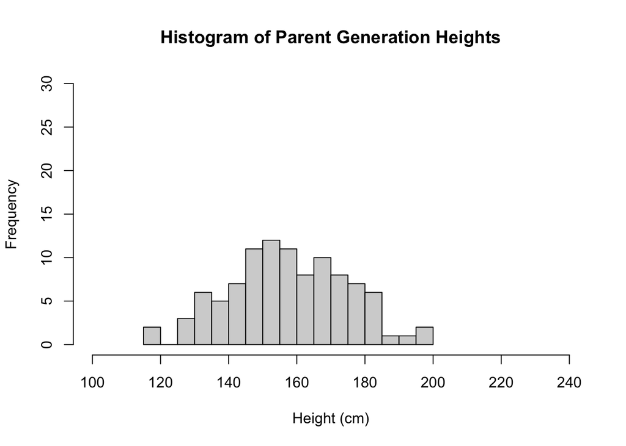

```r
# make it a loop with a counter
# 9 generations, 9 - 1 = 8
# 1:8 to 2:9 so I can include the parent generation in the same list

f_gens <- list(pop) # list of data frames

# generate another 8 generations
for (i in 2:9) {
  f_gens[[i]] <- next_gen(f_gens[[(i-1)]]) # be careful to reference the previous generation, not just the parent pop
}

# histograms
hist(f_gens[[1]]$m, breaks=15, xlim=range(100,240), ylim=range(0,30), main='Histogram of Parent Generation Heights', xlab='Height (cm)')
```

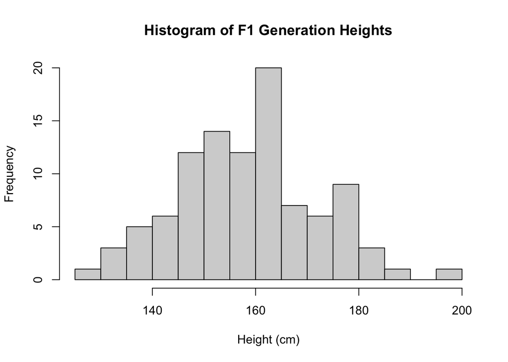

```r
hist(f_gens[[2]]$m, breaks=15, main='Histogram of F1 Generation Heights', xlab='Height (cm)')
```

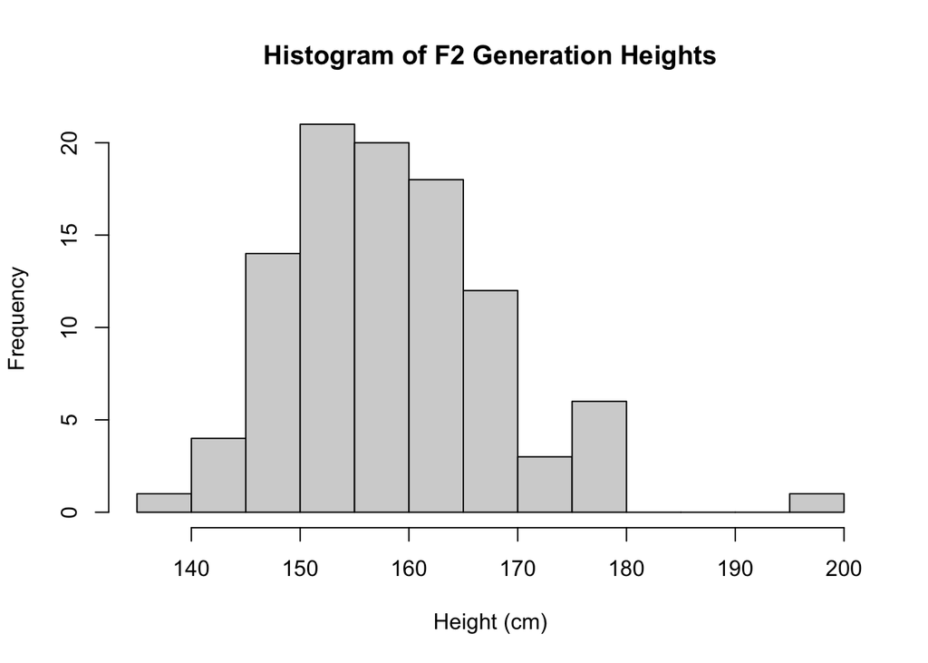

```r
hist(f_gens[[3]]$m, breaks=15, main='Histogram of F2 Generation Heights', xlab='Height (cm)')
```

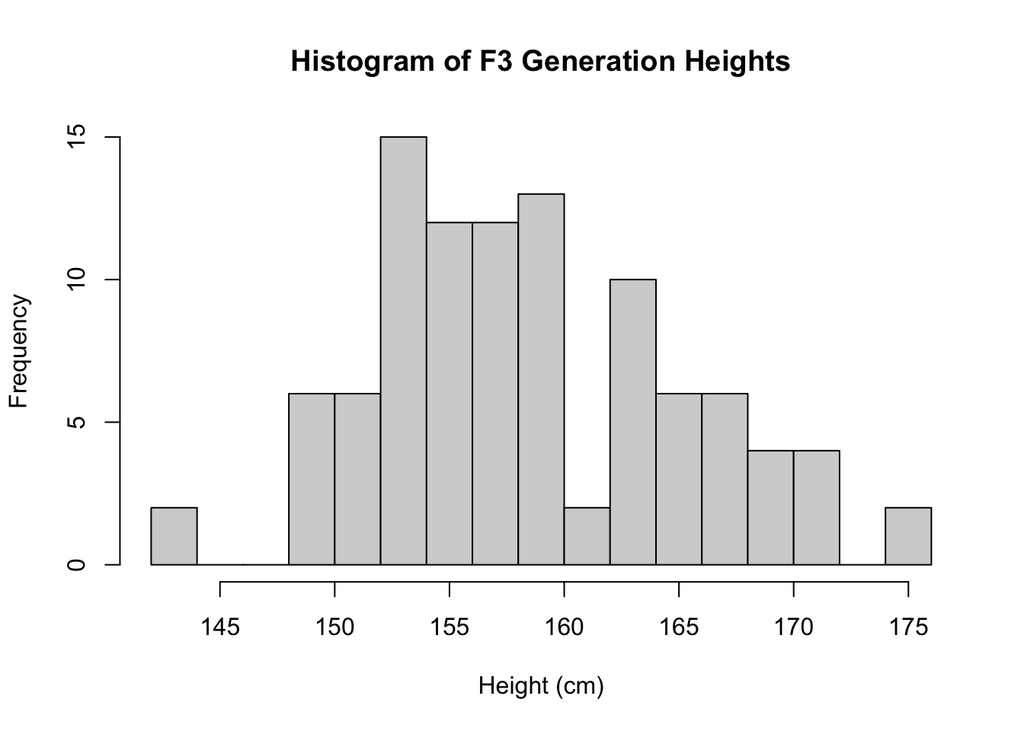

```r
hist(f_gens[[4]]$m, breaks=13, main='Histogram of F3 Generation Heights', xlab='Height (cm)')
```

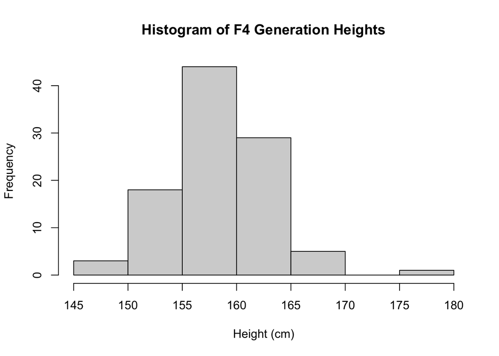

```r
hist(f_gens[[5]]$m, breaks=10, main='Histogram of F4 Generation Heights', xlab='Height (cm)')
```

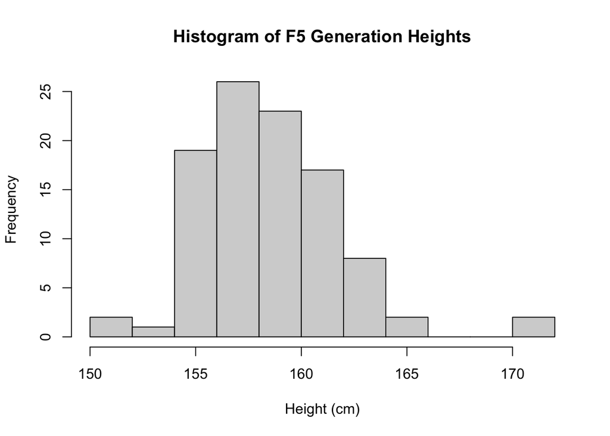

```r
hist(f_gens[[6]]$m, breaks=10, main='Histogram of F5 Generation Heights', xlab='Height (cm)')
```

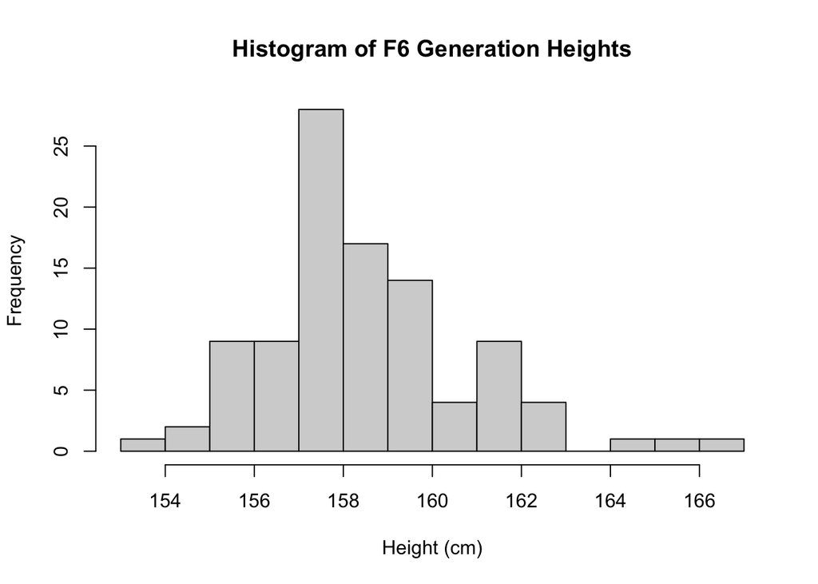

```r
hist(f_gens[[7]]$m, breaks=15, main='Histogram of F6 Generation Heights', xlab='Height (cm)')
```

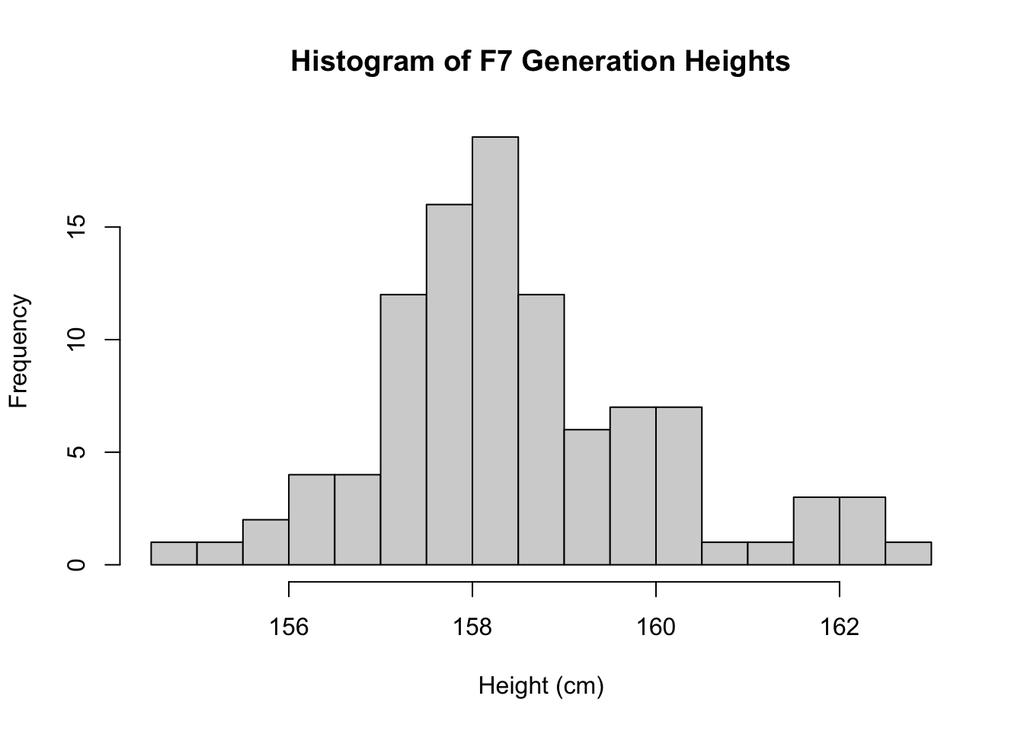

```r
hist(f_gens[[8]]$m, breaks=13, main='Histogram of F7 Generation Heights', xlab='Height (cm)')
```

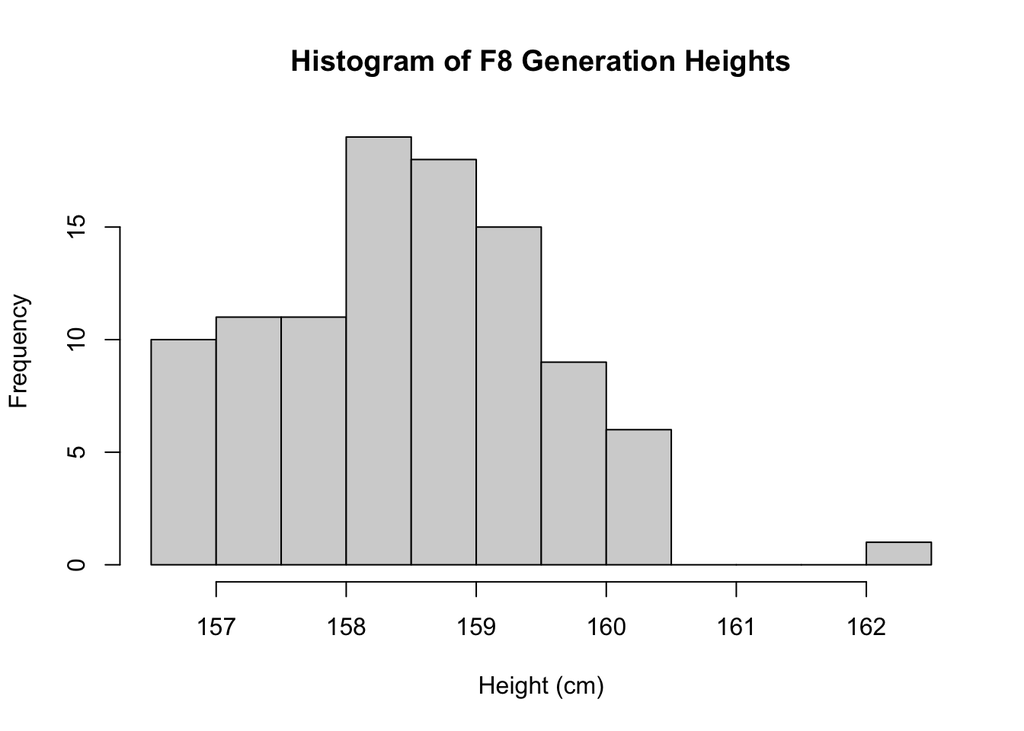

```r
hist(f_gens[[9]]$m, breaks=10, main='Histogram of F8 Generation Heights', xlab='Height (cm)')
```

### Question 2

**10 points**

Use the simulated results from question 1 to reproduce (as closely as possible) the following plot in ggplot2.

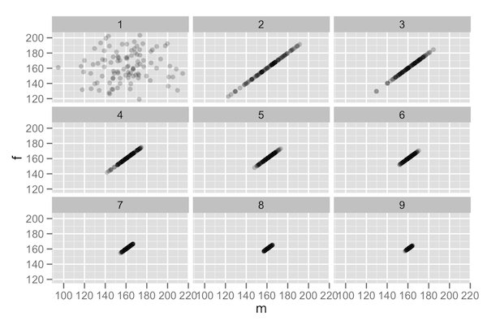

generations plot

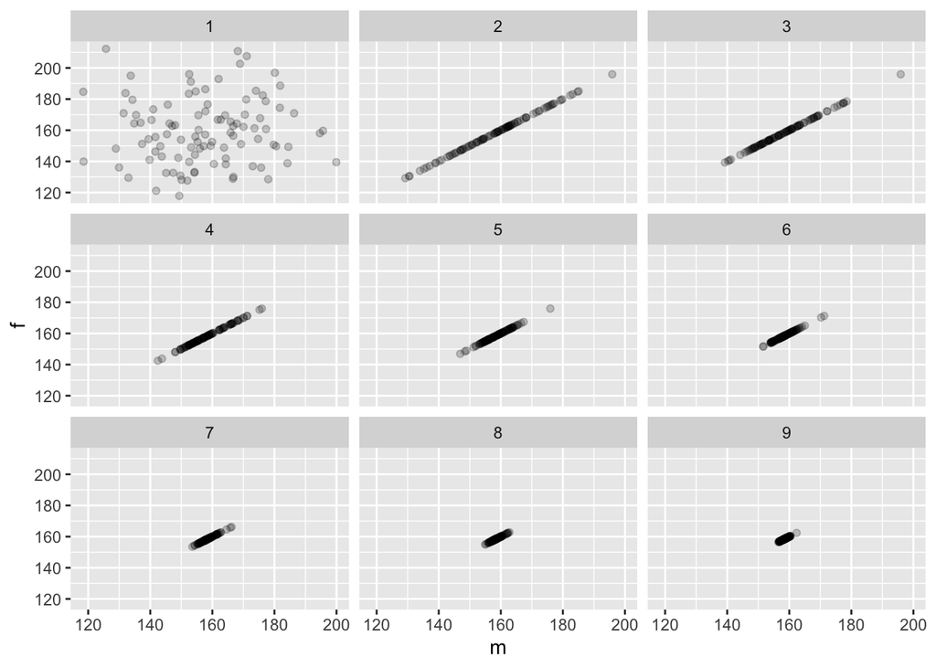

```r
library(ggplot2)
# make a generation variable, I need everything in one dataframe
gen_count <- rep(c(seq(1, 9)), each=100)

multi_gen <- rbind(f_gens[[1]], f_gens[[2]], f_gens[[3]], f_gens[[4]], f_gens[[5]], f_gens[[6]], f_gens[[7]], f_gens[[8]], f_gens[[9]])

total <- cbind(multi_gen, gen_count)

# scatter plot
# all 9 are displayed on 1 device, 3x3
# m along x axis, f along y axis

p = ggplot(data=total) + geom_point(mapping = aes(x=m, y=f), alpha = 0.2)
p + facet_wrap(~ gen_count)
```

### Question 3

**15 points**

You calculated the power of a study design in question #1 of assignment 3. The study has two variables, treatment group and outcome. There are two treatment groups (0, 1) and they should be assigned randomly with equal probability. The outcome should be a random normal variable with a mean of 60 and standard deviation of 20. If a patient is in the treatment group, add 5 to the outcome.

Starting with a sample size of 250, create a 95% bootstrap percentile interval for the mean of each group. Then create a new bootstrap interval by increasing the sample size by 250 until the sample is 2500. Thus you will create a total of 10 bootstrap intervals. Each bootstrap should create 1000 bootstrap samples. (9 points)

```r
# I think I may have misunderstood what this question wants. The example plot is much more variable than mine, which is pretty stable at 60 and 65. I think I'm having trouble understanding what '1000' bootstrap samples means - but tbh I'm spending a lot of time on this and I need to move on.

# power function from assignment 3
power <- function(sample_size) {
  mean(replicate(1000, {
  treatment <- rbinom(sample_size, 1, 0.5)
  outcome <- rnorm(sample_size, mean=60, sd=20)
  for (i in 1:sample_size) {
    if (treatment[i]==1){
      outcome[i] <- outcome[i] + 5}
    }
  t.test(outcome ~ treatment, alternative='two.sided', mu=0)$p.value
  }) < 0.05)
}

# now working on the homework problem

bootmean_controls <- c()
bootmean_exp <- c()

boot_interval <- function(sample_size) {
  for (k in (1:1000)) { # loop to do the bootstrapping, I find his simpler than doing replicate since I can add means to a vector for later
    treatment <- rbinom(sample_size, 1, 0.5)
    outcome <- rnorm(sample_size, mean=60, sd=20)
      for (i in 1:sample_size) {
        if (treatment[i]==1){
          outcome[i] <- outcome[i] + 5
        }
      }
    df <- data.frame(treatment, outcome) # I'm doing this so I can specify controls vs treatments
    controls <- df[which(df['treatment']==as.integer(0)),]['outcome'][['outcome']] # controls
    exp <- df[which(df['treatment']==as.integer(1)),]['outcome'][['outcome']] # treatment, I want them both to be vectors
    bootmean_controls[k] <- mean(controls)
    bootmean_exp[k] <- mean(exp)
  }
  final_control_mean <- mean(bootmean_controls)
  final_exp_mean <- mean(bootmean_exp)
  control_interval <- mean(bootmean_controls) + qnorm(c(0.05, 0.95)) * sd(bootmean_controls) / sqrt(length(bootmean_controls))
  exp_interval <- mean(bootmean_exp) + qnorm(c(0.05, 0.95)) * sd(bootmean_exp) / sqrt(length(bootmean_exp))
  # return all my stuff
  mean_vector <- c(final_control_mean, final_exp_mean)
  interval_vector_lower <- c(control_interval[1], exp_interval[1])
  interval_vector_higher <- c(control_interval[2], exp_interval[2])
  treatment_vector <- c(0, 1)
  df_total <- data.frame(
    mean_vector,
    interval_vector_lower,
    interval_vector_higher,
    rep(sample_size, 2),
    treatment_vector
    )
  colnames(df_total) = c('mean', 'low', 'high', 'sample', 'treatment')
  df_total
}

boot_list <- seq(from=250, to=2500, by=250) # now to increase the sample size

# I originally wanted to combine these into one dataframe using a loop, but I was having trouble getting it to work
boot_data <- rbind(boot_interval(250), boot_interval(500), boot_interval(750), boot_interval(1000), boot_interval(1250), boot_interval(1500), boot_interval(1750), boot_interval(2000), boot_interval(2250), boot_interval(2500))

boot_data # all info in one dataframe, with a column clarifying treatment vs control
```

| mean | low | high | sample | treatment |
| --- | --- | --- | --- | --- |
| 60.03690 | 59.94515 | 60.12866 | 250 | 0 |
| 65.03339 | 64.93750 | 65.12928 | 250 | 1 |
| 59.95484 | 59.88945 | 60.02023 | 500 | 0 |
| 64.93567 | 64.86821 | 65.00314 | 500 | 1 |
| 59.98297 | 59.92864 | 60.03729 | 750 | 0 |
| 64.95198 | 64.89819 | 65.00578 | 750 | 1 |
| 60.01073 | 59.96576 | 60.05570 | 1000 | 0 |
| 64.97521 | 64.92918 | 65.02123 | 1000 | 1 |
| 59.95048 | 59.91002 | 59.99093 | 1250 | 0 |
| 65.02399 | 64.98369 | 65.06429 | 1250 | 1 |

[output cut: 10 more lines]

Produce a line chart that includes the bootstrapped mean and lower and upper percentile intervals for each group. Add appropriate labels and a legend. (6 points)

You may use base graphics or ggplot2. It should look similar to this (in base).

[figure not shown]

bp interval plot

Here’s an example of how you could create transparent shaded areas.

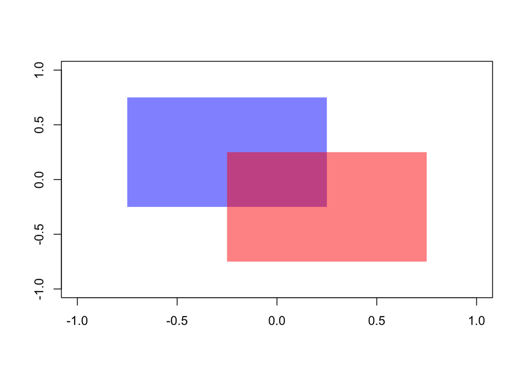

```r
makeTransparent = function(..., alpha=0.5) {
  if(alpha<0 | alpha>1) stop("alpha must be between 0 and 1")
  alpha = floor(255*alpha)
  newColor = col2rgb(col=unlist(list(...)), alpha=FALSE)
  .makeTransparent = function(col, alpha) {
    rgb(red=col[1], green=col[2], blue=col[3], alpha=alpha, maxColorValue=255)
  }
  newColor = apply(newColor, 2, .makeTransparent, alpha=alpha)
  return(newColor)
}

par(new=FALSE)
plot(NULL,
  xlim=c(-1, 1),
  ylim=c(-1, 1),
  xlab="",
  ylab=""
)

polygon(x=c(seq(-0.75, 0.25, length.out=100), seq(0.25, -0.75, length.out=100)),
        y=c(rep(-0.25, 100), rep(0.75, 100)), border=NA, col=makeTransparent('blue',alpha=0.5))
polygon(x=c(seq(-0.25, 0.75, length.out=100), seq(0.75, -0.25, length.out=100)),
        y=c(rep(-0.75, 100), rep(0.25, 100)), border=NA, col=makeTransparent('red',alpha=0.5))
```

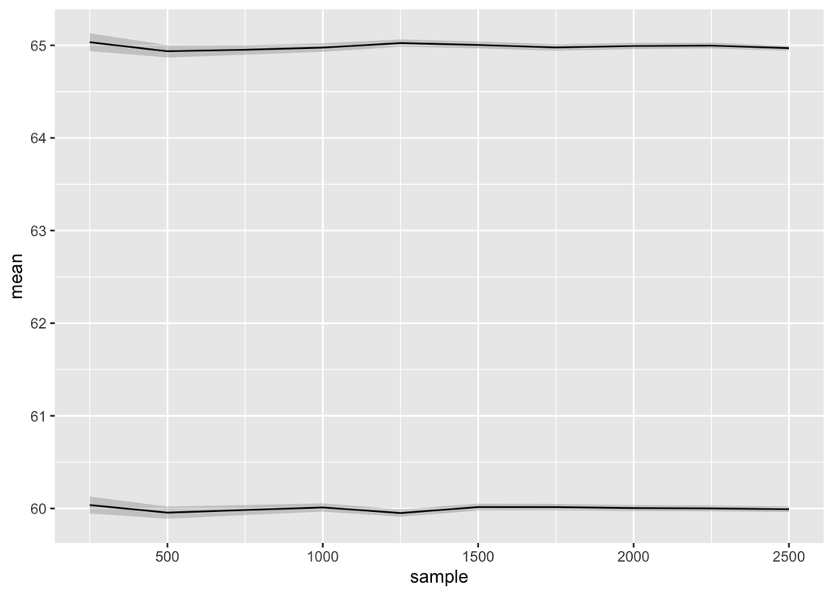

```r
# ggplot
plot <- ggplot(data=boot_data) + geom_line(mapping = aes(x=sample, y=mean, group=treatment)) #geom=c("ribbon")(aes(ymin=low, ymax=high))

plot + geom_ribbon(aes(x=sample, y=mean, group=treatment, ymin = low, ymax = high), alpha = 0.2)
```